# Chapter 3

### Finding Our Parameters

Okay, now that everything seems to be ready, let’s actually use `optim` to get answers for each of the criteria we programmed in above. Note how maximization is done for the likelihood criteria by using the `control` option for `optim`. I’ve plotted the results after doing the fitting.

```r
#### Note that ... arguments, must match EXACTLY.
ChebyFit <- optim(guess, objectiveFn, xvals = x, yvals = y)
MeanADFit <- optim(guess, objectiveFn, xvals = x, yvals = y, dist = "meanAD")
LSQFit <- optim(guess, objectiveFn, xvals = x, yvals = y, dist = "leastSq")
MedianADFit <- optim(guess, objectiveFn, xvals = x, yvals = y, dist = "medianAD")

### We want to MAXIMIZE log likelihood! Use the control() argument.
LLFit <- optim(guess, objectiveFn, xvals = x, yvals = y, dist = "llnorm", control = list(fnscale = -1))

plot(x,y)
abline(LLFit$par, col = "red")
```

```r
abline(ChebyFit$par, col = "blue")
abline(LSQFit$par, col = "green", lty=2)
```

```r
abline(MeanADFit$par, col = "black", lty = 3)
abline(MedianADFit$par, col = "orange")
```

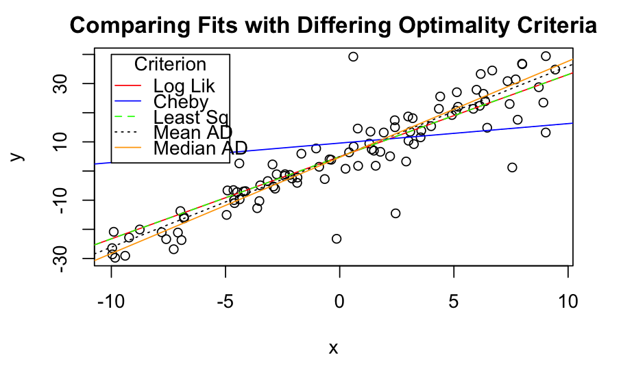

```r
legend(-10, 40, c("Log Lik", "Cheby", "Least Sq", "Mean AD", "Median AD"),
       col = c("red", "blue", "green", "black", "orange"), lty = c(1,1,2,3,1), pch = NA,
       title = "Criterion")
title("Comparing Fits with Differing Optimality Criteria")
```

Two things to notice in the above. One is just to see that `optim` returns (by default) a list of five elements:

- `par` has the parameter values
- `value` has the last value returned by the objective function
- `counts` tell you how many step the algorithm took
- `convergence` is 0 if the algorithm converged on a solution; it is 1 if it did not
- `message` has any messages relevant to the fitting

Typically, we care about convergence and the parameter estimates. For some applications, you may care about things such as the Hessian matrix, which must be requested.

Let’s try the same exercise using Python’s `minimize()` routine:

```python
reticulate::repl_python()
```

```
Python 3.9.6 (/Users/bridenho/opt/anaconda3/envs/r-reticulate/bin/python)
Reticulate 1.20 REPL -- A Python interpreter in R.
```

```python
import scipy.optimize as optim

ChebyFit = optim.minimize(objectiveFn, guess, args=(x,y), method = 'Nelder-Mead')
MeanADFit = optim.minimize(objectiveFn, guess, args=(x,y,meanAD), method = 'Nelder-Mead')
LSQFit = optim.minimize(objectiveFn, guess, args=(x,y,leastSq), method = 'Nelder-Mead')
MedianADFit = optim.minimize(objectiveFn, guess, args=(x,y,medianAD), method = 'Nelder-Mead')

#note the use of the -1 being passed to the "sign" argument to switch to maximization
LLFit = optim.minimize(objectiveFn, guess, args=(x,y,llnorm,-1), method = 'Nelder-Mead')

###show estimates of R vs Python
print('Chebyshev in R:', r.ChebyFit['par'])
```

```
Chebyshev in R: [9.606091608333498, 0.6696472494310486]
```

```python
print('Chebyshev in Python:', ChebyFit.x)
```

```
Chebyshev in Python: [9.60608716 0.66964538]
```

```python
print('Mean Absolute Deviation in R:', r.MeanADFit['par'])
```

```
Mean Absolute Deviation in R: [4.921165938127439, 3.1036401166919645]
```

```python
print('Mean Absolute Deviation in Python:', MeanADFit.x)
```

```
Mean Absolute Deviation in Python: [4.92131493 3.1036159 ]
```

```python
print('Least Squares in R:', r.LSQFit['par'])
```

```
Least Squares in R: [4.919448998034824, 2.816603728218582]
```

```python
print('Least Squares in Python:', LSQFit.x)
```

```
Least Squares in Python: [4.92050527 2.81663859]
```

```python
print('Median Absolute Deviation in R:', r.MedianADFit['par'])
```

```
Median Absolute Deviation in R: [4.69723477405052, 3.2974217625145035]
```

```python
print('Median Absolute Deviation in Python:', MedianADFit.x)
```

```
Median Absolute Deviation in Python: [-1.30366211  4.09940672]
```

```python
print('Maximum Likelihood in R:', r.LLFit['par'])
```

```
Maximum Likelihood in R: [4.919448998034824, 2.816603728218582]
```

```python
print('Maximum Likelihood in Python:', LLFit.x)
```

```
Maximum Likelihood in Python: [4.92050527 2.81663859]
```

Because we know the true parameters from our simulated data, we have the luxury or assessing which method performed the best. We can do this by calculating the distance between our points and the “truth” in model space. Let’s see which one worked best:

```r
dMat <- data.frame("Criteria" = c("Chebysev", "Mean Absolute Deviation", "Least Squares",
                                       "Median Absolute Deviation", "Maximum Likelihood"),
           "Distance" = c((t(ChebyFit$par) %*% c(3,5))^0.5, (t(MeanADFit$par) %*% c(3,5))^0.5,
                          (t(LSQFit$par) %*% c(3,5))^0.5, (t(MedianADFit$par) %*% c(3,5))^0.5,
                          (t(LLFit$par) %*% c(3,5))^0.5))

dMat[order(dMat$Distance),]
```

|  | Criteria | Distance |
| --- | --- | --- |
| 3 | Least Squares | 5.370416 |
| 5 | Maximum Likelihood | 5.370416 |
| 2 | Mean Absolute Deviation | 5.502881 |
| 4 | Median Absolute Deviation | 5.529811 |
| 1 | Chebysev | 5.671553 |

## Examining Optimization Algorithms

Try the following code to see the value of our objective function for different methods available in `optim` and usable for our problem:

```r
objFns <- c("chebyshev","leastSq","llnorm","meanAD","medianAD")
algs <- c("Nelder-Mead", "BFGS", "CG", "L-BFGS-B", "SANN")
vals <- matrix(NA, ncol = length(objFns), nrow = length(algs))
colnames(vals) <- objFns
rownames(vals) <- algs

for(i in 1:length(objFns)){
  clist <- if(objFns[i] == "llnorm") list(fnscale = -1) else list()
  for(j in 1:length(algs)) vals[j,i]<-optim(guess, objectiveFn, xvals = x, yvals = y,
                                            dist = objFns[i], method = algs[j], control = clist)$value
}

vals
```

```
            chebyshev  leastSq    llnorm   meanAD medianAD
Nelder-Mead  32.75658 94.65273 -4824.530 5.614784 2.955142
BFGS         33.28067 94.65273 -4824.530 5.616005 3.414107
CG           39.82739 94.65273 -4824.531 5.626862 3.964918
L-BFGS-B     32.75759 94.65273 -4824.530 5.614788 3.167710
SANN         32.77424 94.65276 -4824.532 5.615043 2.955304
```

Which algorithm performed the best? Which one performed the worst? It is worthwhile to note that the simulated annealing algorithm (`SANN`) uses randomization and thus will return different results with every run (hopefully not very different). There are certain situations where simulated annealing may be your best option. Sometimes, best estimates can achieved by running combinations algorithms (e.g., the first stage might use `BFGS` and the second stage could use `Nelder-Mead`).